# **Customer Segmentation**

[Okino Kamali Leiba](https://www.linkedin.com/in/okinoleiba)

### Parameters

- Use case: Identify market segment from a larger population.
- Data: Really fake data from our really fake mall.
- Tools: Jupyter Notebook
- Cross-instrument: none
- Documentation: none

### Table of Content

- Introduction
- Exploratory Data Analysis
- Create Segments and Clusters (KMeans Clustering Algorithm)
- Final Analysis

### Introduction

Imports

- SYS module for access to variables and functions used or maintained by the interpreter
- Pandas for data analysis and manipulation
- Numpy for general array computations
- Matplotlib for creating static, animated, and interactive visualizations in Python
- Seaborn for Python data visualization based on Matplotlib
- Scikit-Learn for machine learning library that supports supervised and unsupervised learning

```python
import sys, pandas as pd, numpy as np, matplotlib as plt, seaborn as sns
import warnings
warnings.filterwarnings("ignore")
ImportWarning.__suppress_context__
```

```
<member '__suppress_context__' of 'BaseException' objects>
```

```python
file_path="/Users/Owner/source/vsc_repo/customer_segment_cookbook/mall_customers.csv"
segment_data = pd.read_csv(file_path, delimiter=",", header=0, nrows=300, na_values="NaN", keep_default_na=True, skip_blank_lines=False,
encoding="utf-8")
segment_data.columns
```

```
Index(['CustomerID', 'Gender', 'Age', 'Annual Income (k$)',
       'Spending Score (1-100)'],
      dtype='object')
```

### Exploratory Data Analysis

```python
segment_data.head(5)
```

|  | CustomerID | Gender | Age | Annual Income (k$) | Spending Score (1-100) |
| --- | --- | --- | --- | --- | --- |
| 0 | 1 | Male | 19 | 15 | 39 |
| 1 | 2 | Male | 21 | 15 | 81 |
| 2 | 3 | Female | 20 | 16 | 6 |
| 3 | 4 | Female | 23 | 16 | 77 |
| 4 | 5 | Female | 31 | 17 | 40 |

```python
segment_data.tail(5)
```

|  | CustomerID | Gender | Age | Annual Income (k$) | Spending Score (1-100) |
| --- | --- | --- | --- | --- | --- |
| 195 | 196 | Female | 35 | 120 | 79 |
| 196 | 197 | Female | 45 | 126 | 28 |
| 197 | 198 | Male | 32 | 126 | 74 |
| 198 | 199 | Male | 32 | 137 | 18 |
| 199 | 200 | Male | 30 | 137 | 83 |

```python
segment_data.info
```

```
<bound method DataFrame.info of      CustomerID  Gender  Age  Annual Income (k$)  Spending Score (1-100)
0             1    Male   19                  15                      39
1             2    Male   21                  15                      81
2             3  Female   20                  16                       6
3             4  Female   23                  16                      77
4             5  Female   31                  17                      40
..          ...     ...  ...                 ...                     ...
195         196  Female   35                 120                      79
196         197  Female   45                 126                      28
197         198    Male   32                 126                      74
198         199    Male   32                 137                      18
199         200    Male   30                 137                      83

[200 rows x 5 columns]>
```

```python
if all(segment_data.isna()) or all(segment_data.isnull()):
    print("All Good")
else:
    print("Danger, Will Robinson")
```

```
All Good
```

```python
segment_data[["Age", "Annual Income (k$)", "Spending Score (1-100)"]].describe().round(decimals=3)
```

|  | Age | Annual Income (k$) | Spending Score (1-100) |
| --- | --- | --- | --- |
| count | 200.000 | 200.000 | 200.000 |
| mean | 38.850 | 60.560 | 50.200 |
| std | 13.969 | 26.265 | 25.824 |
| min | 18.000 | 15.000 | 1.000 |
| 25% | 28.750 | 41.500 | 34.750 |
| 50% | 36.000 | 61.500 | 50.000 |
| 75% | 49.000 | 78.000 | 73.000 |
| max | 70.000 | 137.000 | 99.000 |

```python
count_data = segment_data['Spending Score (1-100)'].value_counts(normalize=True, sort=True, ascending=True).round(decimals=3)
count_data

# columns = ['Age', 'Annual Income (k$)','Spending Score (1-100)']
# count_data = []
# for iterable in columns:
#     count_data = segment_data[iterable].value_counts(normalize=True, sort=True, ascending=True).round(decimals=3)
#     # print(count_data[iterable])
# count_data
```

```
18    0.005
44    0.005
45    0.005
11    0.005
9     0.005
      ...
50    0.025
46    0.030
73    0.030
55    0.035
42    0.040
Name: Spending Score (1-100), Length: 84, dtype: float64
```

**Univariate Analysis and Visualization**

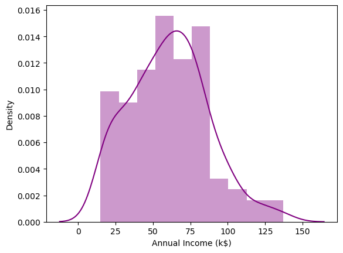

```python
sns.distplot(segment_data["Annual Income (k$)"], color="purple",hist=True);
```

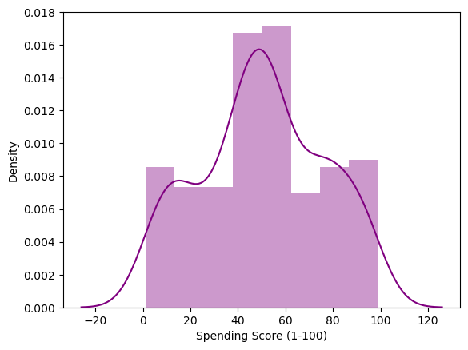

```python
sns.distplot(segment_data["Spending Score (1-100)"], kde=True, color="purple");
```

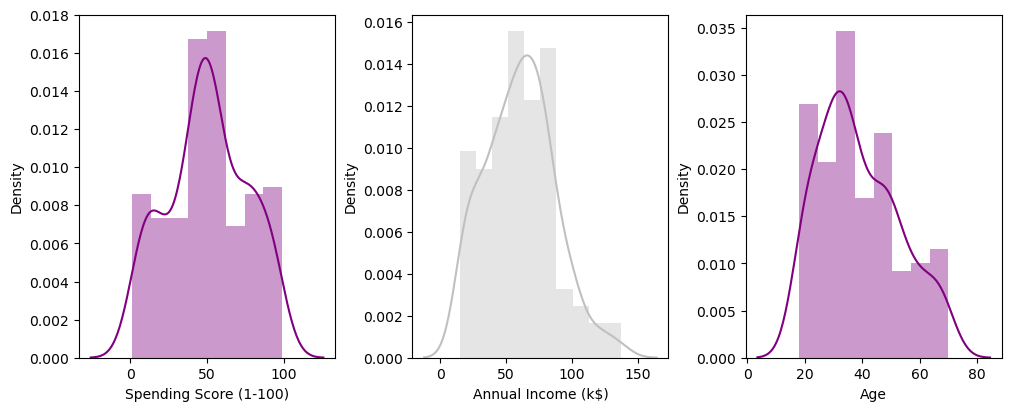

```python
fig, axe = plt.pyplot.subplots(nrows=1,ncols=3, constrained_layout=True, figsize=(10, 4))

sns.distplot(segment_data["Spending Score (1-100)"], kde=True, color="purple", ax=axe[0]);
sns.distplot(segment_data["Annual Income (k$)"], color="silver",hist=True, ax=axe[1]);
sns.distplot(segment_data["Age"], color="purple",hist=True, ax=axe[2]);

# fig = plt.pyplotfigure(constrained_layout=True, figsize=(10, 4))
# subfigs = fig.subfigures(1, 2, wspace=0.07)
# sns.distplot(segment_data["Spending Score (1-100)"], kde=True, color="silver", ax=subfigs[0]);
# sns.distplot(segment_data["Annual Income (k$)"], color="orange",hist=True, ax=subfigs[1]);
# sns.distplot(segment_data["Age"], color="orange",hist=True, ax=subfigs[2]);
```

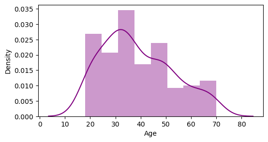

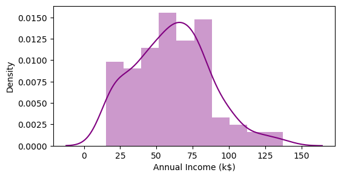

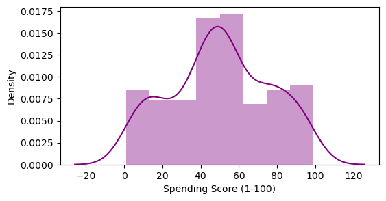

```python
columns = ['Age', 'Annual Income (k$)','Spending Score (1-100)']
for iterable in columns:
    fig = plt.pyplot.figure(figsize=(6, 3))
    # fig, axe = plt.pyplot.subplots(nrows=1,ncols=3)
    # fig, axe = plt.pyplot.subplots(nrows=1,ncols=3, constrained_layout=True, figsize=(10, 4))
    sns.distplot(segment_data[iterable], color="purple",hist=True);
```